Survival analyses are used in all sorts of different fields from medicine to finance, and involve data where researchers have measured *how long it takes for an event to happen*. In the environmental sciences, the term ‘survival’ tends to be obvious, and these analyses are frequently used to analyse patterns in the time it takes an organism to die - referred to as ‘time to death’.

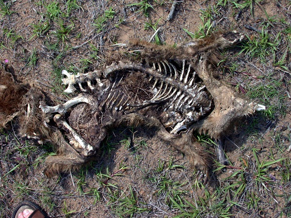

This tutorial is an introduction to Kaplan-Meier survival curves. These analyses can create and contrast curves that show the proportional survival among groups of organisms, help predict how subjects will respond to different environmental factors, and will determine which factors have the most significant impact on survival.

A few quick definitions before we start

- **Survival function:** the probability of an individual surviving to time *x*
- **Hazard rate/risk function:** the chance an individual at *x* will experience the event
- **Mean residual life:** the mean time to the event of interest
- **Probability density/probability mass function:** unconditional probability of the event occurring at time *x*

**Censored data.** This tutorial will only cover right-censored data. Censoring data keeps information from being lost during the analysis period as subjects that do not show a response do not have to be removed from the data set. For example, if at the end of a one hour observation period, 90% of the subjects died and 10% were still alive, the event time for the 10% would be included in the analysis and noted as still alive at 1 hour (the end of the experiment), rather than dead at 1 hour. This is right censored data and the analysis takes this factor in consideration.

### Running the analysis

Your data set should have the following information: the measured response time (time to death or time to event) and the censor (0 for alive or 1 for dead) and other categorical or continuous factors that you would like to analyse (such as sex, age, exposed temperature, etc.)

For this worked example, download a sample data set on the survival of two species of organisms in a thermal stress experiment, Exp_survival.csv and import into R. The variables are time to death, the censor, species (A or B), sex (male or female) and size (small and large).

```r
Exp_survival <- read.csv(file = "Exp_survival.csv", header = TRUE)
```

Install the package, [survival](https://cran.r-project.org/web/packages/survival/index.html) and load into R.

```r
library(survival)
```

First, use the `Surv` function to create a ‘survival object’ that will be the foundation of your analysis and will be used for all comparitive and predictive models you will create. The arguments of `Surv` used here are when the event happened (time to death), and whether the event was observed (censor), and type of censoring.

```r
SurvObj <- Surv(time = Exp_survival$Time_to_Death, event = Exp_survival$Censor, type = c('right'))
```

**Plotting survival curves.** The `survfit` function is used to make the survival curve from the survival object. The argument of `survfit` is a formula with the survival object to the left of the ~ and predictor variables to the right. Here will use 1 on the right hand side to obtain a single survival curve for all the organisms in the experiment.

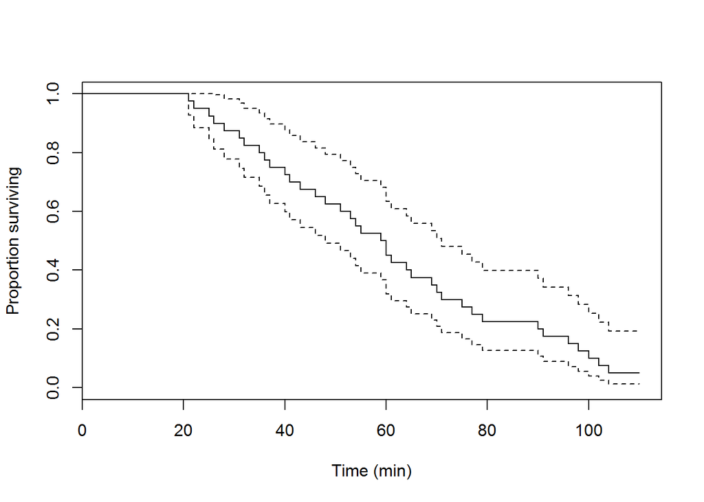

```r
Single_curve <- survfit(SurvObj ~ 1)

plot(Single_curve, xlab = "Time (min)", ylab= "Proportion surviving")
```

This plot provides general proportional survival by time, also known as the Kaplan-Meier estimate. The dashed lines on the plot are 95% confidence bands. Confidence intervals can be added or altered using ,conf.int or ,conf.type arguments for type and size.

**Survival curves with categorical predictors**. We can modify the formula to create survival curves for different groups of organisms in our data set (e.g., species, sex or size).

To contrast the survival curves of the two species in our sample data set, we would use:

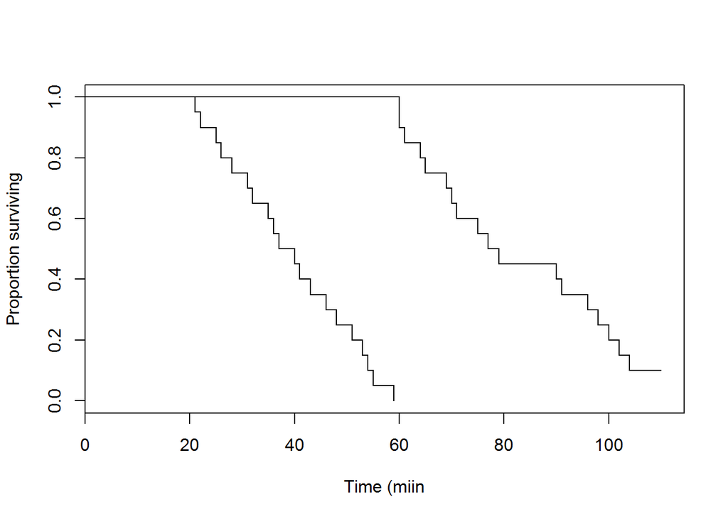

```r
Species_curves <- survfit(SurvObj ~ Exp_survival$Species)

plot(Species_curves, xlab = "Time (miin", ylab= "Proportion surviving")
```

This plots proportional survival by time, splitting the data by the species variable (Species A or Species B).

To contrast survival by species and sex, we would use two preditor variables in our formula:

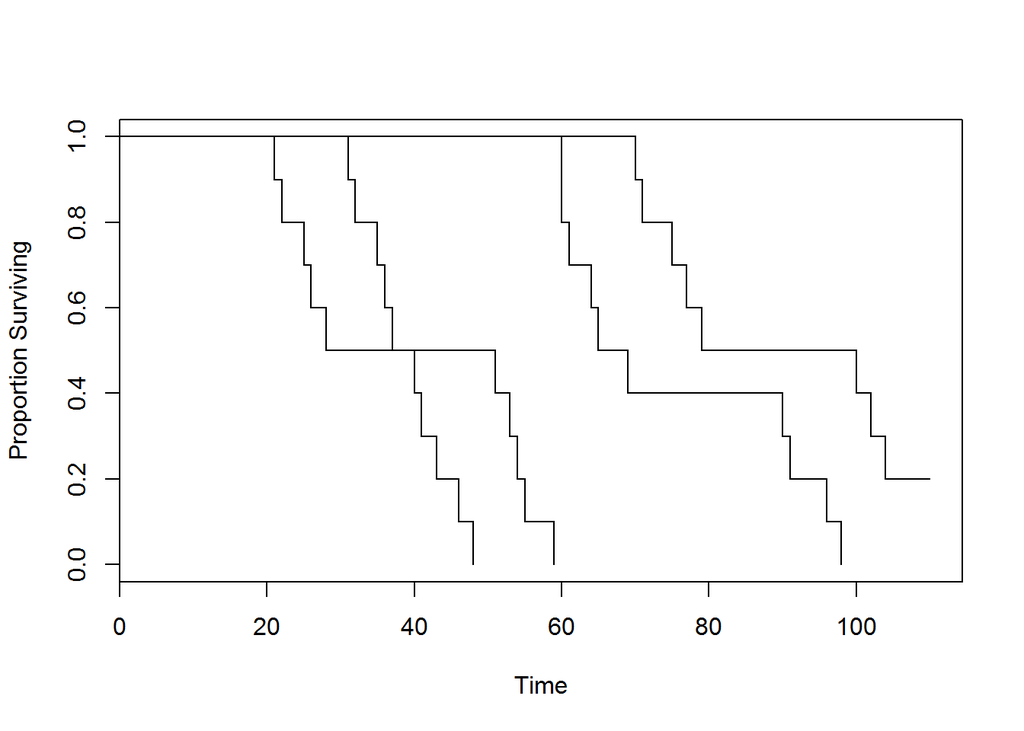

```r
Species_by_sex_curves <-survfit(SurvObj ~ Exp_survival$Species + Exp_survival$Sex)

plot(Species_by_sex_curves, xlab = "Time", ylab= "Proportion Surviving")
```

**Testing for differences in survival.** Following the use of `survfit` to visualise patterns in survival, we can now test whether and differences are significant with the function `survdiff`. For example, to contrast survival between our two species, we would use:

```r
Species_diff <- survdiff(SurvObj ~ Exp_survival$Species)
```

### Interpreting the results

You can see the output from this test by simply entering the name of the new object.

```r
Species_diff
```

```
## Call:
## survdiff(formula = SurvObj ~ Exp_survival$Species)
##
##                                 N Observed Expected (O-E)^2/E (O-E)^2/V
## Exp_survival$Species=Species.A 20       20     6.38     29.04      46.5
## Exp_survival$Species=Species.B 20       18    31.62      5.86      46.5
##
##  Chisq= 46.5  on 1 degrees of freedom, p= 8.99e-12
```

`survdiff` has run a hypothesis test giving evidence for or against species being associated with a difference in survival. The chi-square statistic is used to test whether the actual response is significantly different to the expected response if the two groups had equal survival. In this case, there is a significant difference between the expected and observed (tiny P value), indicating that survival differed between the species under thermal stress.

### Assumptions to check

The Kaplan-Meier survival curve is defined as the probability of surviving in a given length of time while considering time in many small intervals. There are three assumptions that needs to be considered when using Kaplan-Meier curves for survival analysis.

1. Censored observations have the same survival prospects as those who continue to be monitored.
2. Survival probabilities are the same for observations noted early and late in the study.
3. The event happens at the time specified. This creates problem in some conditions when the event would be detected at a regular examination. All we know is that the event happened between two examinations.

### Communicating the results

**Visual.** The survival curves can be used to visualise patterns in the survival data, such as differences between species or sex survival capabilities. The `survival` R package does not create the most visually appealing graphs, but there are other graphing functions utilizing the `ggplot2` package that can be taken advantage of to make publishable quality figures. Visit this [link](https://www.r-statistics.com/2013/07/creating-good-looking-survival-curves-the-ggsurv-function/) to find the function `ggsurv` that can be used to make pretty Kaplan-Meier survival curves using the `survival` package.

**What next?** Once you have started creating survival curves the next step in the analysis is to use Hazard models. Hazard models allow for measured factors to be used in predicting the survival potential of specific observations and communities.

### Further help

Survival analysis and theory:

Diez, DM. 2013. *Survival analysis in R.* OpenIntro. [Find here.](https://www.openintro.org/download.php?file=survival_analysis_in_R&referrer=/stat/surv.php)

Klein and Moeschberger (2003) *Survival analysis: Techniques for censored and truncated data.* Second Edition. Springer. Ch.2. Basic quantities and models.

Norman and Streiner (2008) *Biostatistics: The bare essentials.* Third Edition. People’s Medical Publishing House. Ch. 25. Survival analysis.

Censoring:

Quinn and Keough (2002) *Experimental design and data analysis for biologists.* Cambridge Univeristy Press. Ch. 4. Graphical exploration of data.

Klein and Moeschberger (2003) *Survival Analysis: Techniques for censored and truncated data.* Second Edition. Springer. Ch.3. Censoring and truncation.

**Author**: Janine Ledet  
Last updated:

```
## [1] "Mon Aug 08 12:01:15 2016"
```